[figure not shown]

Graduate Research Plan Statement: L. K. Puckett

Computational Black Spruce Cover Mapping and Inference of Fire-Forest Interactions across

the North American Boreal Forest

The area of land burned by wildfires in the North American boreal forest has doubled in recent decades

1

.

Complex fire-forest-climate feedbacks could lead to destabilizing effects on climate and boreal forest

ecosystem composition

2

. Black spruce (Picea mariana) dominated forests are an important component of

these feedbacks because black spruce are more flammable than other boreal forest species (birch, aspen,

white spruce, larch, pine) and these forests are characterized by deep carbon-rich organic soils that

accumulate over hundreds to thousands of years. An increase in carbon emissions due to the combustion

of boreal soils could lead to further climate warming and increased fire risk

3

, a powerful positive

feedback cycle exacerbating warming. However, a state change from black spruce to other forest

composition typically occurs after high severity fires combust organic soil layers

4

. Resulting succession to

less flammable broadleaf forest across the landscape is hypothesized to act as firebreaks

5

and provide a

stabilizing feedback. The interaction of these mechanisms across broad spatial scales has not been

addressed due to a lack of species-specific forest composition maps. Advances in computing in addition

to the recent acquisition of large-scale field, airborne and satellite datasets now make species-level

mapping possible across boreal North America. I propose to map black spruce fractional cover at high

resolution across this biome for two time periods and investigate large scale fire-forest interactions. This

work will establish a reference baseline for the current state and dynamics of the system, a crucial step

towards anticipating future change.

Research Objectives (RO) and Hypotheses (H)

RO1: Map black spruce fractional cover over the study domain for years 2000 and 2020 at 30m resolution

using machine learning to link extensive forest inventory data with airborne and satellite data

RO2: Test fire-forest feedback hypotheses across large spatial extent:

H1: Black spruce forests have higher probability of burning than other forests

H2: The probability of burning increases with the size of contiguous forest patches

H3: High severity fires favor succession to deciduous rather than black spruce forest

H4: Black spruce forests become more fragmented as a result of fire disturbance

RO3: Identify areas and methods to focus fire risk management

Research Plan

Existing Geospatial Datasets – Field measurements of forest cover will be used for model training and

validation (figure 1). Hyperspectral imagery at 5m spatial and 5nm radiometric resolution, and 10m

footprint waveform LiDAR data have been collected from 2017-2019 (figure 1). Fire perimeter maps are

publicly available for the study area over the time period 1984-2018. I have access to all these data.

Develop Black Spruce Fractional Cover Maps (RO1) – Co-located hyperspectral and LiDAR data, which

have been used to accurately classify forest species in the Pacific Northwest

6

will be used to map black

spruce fractional cover, that is, the areal proportion of a pixel occupied by the canopy, at 10m resolution.

The resulting classified areas will be aggregated to 30m resolution and used as training data for

subsequent modeling over the entire study area, increasing the sample size to more than 1 million pixels.

Machine-learning algorithms (e.g. random forest, support vector machines, gradient boosting) will be

utilized on high-performance computing platforms to model black spruce fractional cover and its

uncertainty over the entire study area using predictors including Landsat satellite image time series and

existing climate, soil, and topographic datasets. The model will be applied in years 2000 and 2020 and

accuracy, error, and uncertainty will be characterized using data from reserved field site samples

distributed across the study region (figure 1). Best practices for spatial validation

7

, will be followed to

ensure that training and testing datasets are not spatially autocorrelated.

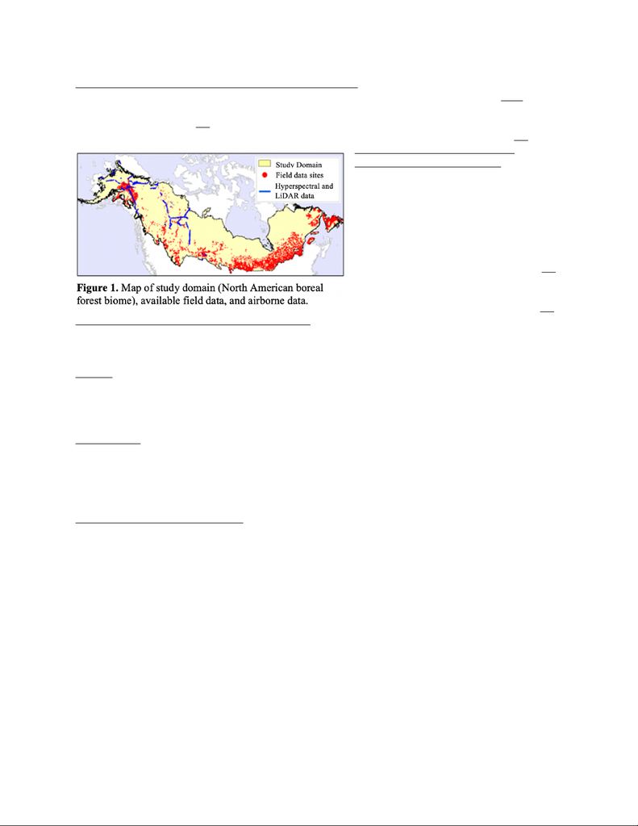

Influence of forest type on fire probability and severity (RO2) – The area of black spruce dominant forest

(>50% fractional cover black spruce) and total forest will be calculated using the maps from RO1. The

proportion of total black spruce forest and other forest types that burned over the study period will be

calculated and compared (H1). Contiguous black spruce dominant pixels will be considered a “patch” and

the relationship between patch size and percent burned over the study period will be evaluated (H2).

Changes in forest composition and

fragmentation due to fire (RO2) – A

satellite-based measure of burn severity (e.g.,

differenced normalized burn ratio) will be

calculated from Landsat data and used to

extract a stratified random subset of fires

between 2001 and 2005. Burn severity and

change in black spruce fractional cover will

be analyzed to determine if higher severity

fires led to detectable forest conversion (H3).

The average black spruce patch size will be

compared between 2000 and 2020 to test the

extent to which fragmentation changed (H4).

Identify areas to focus fire-risk management (RO3) - Based on results of the preceding analysis, locations

with high fire risk will be identified as recommended areas to assess forest management practices.

Proximity to human population centers will also be considered to prioritize management of forests at the

highest risk for impacting air quality and infrastructure.

Skill Set – I am proficient in R, Google Earth Engine, Python, and Bash and have experience working

with large-scale geospatial data using the high-performance computing cluster (Monsoon) at Northern

Arizona University (NAU). Google Earth Engine is ideally suited for preprocessing large amounts of

Landsat imagery, which can then be used with machine learning algorithms on a computing cluster such

as Monsoon. I also have experience doing fieldwork in recently burned and mature boreal forest types.

Collaborators – I collaborate with researchers at NAU (Global Earth Observation and Dynamics of

Ecosystems Lab, Center for Ecosystem Science and Society) and other institutions (Alaska Fire Science

Consortium (AFSC), Woodwell Climate Research Center, Alaska Biological Research Inc.) who are

experts in boreal forest fire dynamics and large-scale mapping using aerial and satellite data.

Intellectual Merit

Black Spruce Fractional Cover Map – This project will utilize state-of-the-art machine learning

techniques and newly available field and remote sensing datasets to map black spruce cover across the

North American boreal forest. Black spruce forests have distinct properties (biomass density, structure,

fuel characteristics) that are not captured by currently available coniferous/broadleaf maps.

Broader Impacts

This work will involve a network of collaborators (listed above) and will generate results that will inform

scientists and forest managers about vegetation-fire feedbacks over the study area in recent decades. The

identification of high-risk areas for large and potentially severe fires will provide valuable insight to

forest managers for mitigating carbon emissions from combustion, harmful impacts of smoke, and

damage to structures and timber resources. Maps will be shared on public archives such as the ORNL

DAAC and as Google Earth Engine assets. All code used to produce maps or results will be publicly

available to ensure reproducibility. Outreach to fire managers will be facilitated by the AFSC.

References. [1] Kasischke et al. Geophys. Res. Lett. 33, (2006). [2] Johnstone et al. Landsc. Ecol. 26,

487–500 (2011). [3] Walker et al. Nature 572, 520–523 (2019). [4] Johnstone et al. Ecosphere 11(5),

(2020). [5] Terrier, et al. Ecol. Appl. 23, 21–35 (2013). [6] Jones et al. Remote Sens. Environ. 114, 2841-

2852 (2010). [7] Ploton et al. Nat. Commun. 11, 1-11 (2020).